# Computer Lab 1

where I 0 (κ) is the modified Bessel function of the first kind of order zero [see ?besselI in R]. The parameter μ (−π ≤ μ ≤ π) is the mean direction and κ > 0 is called the concentration parameter. Large κ gives a small variance around μ, and vice versa. Assume that μ is known to be 2.39. Let κ ∼ Exponential(λ = 1) a priori, where λ is the rate parameter of the exponential distribution (so that the mean is 1/λ). (a) Plot the posterior distribution of κ for the wind direction data over a fine grid of κ values.

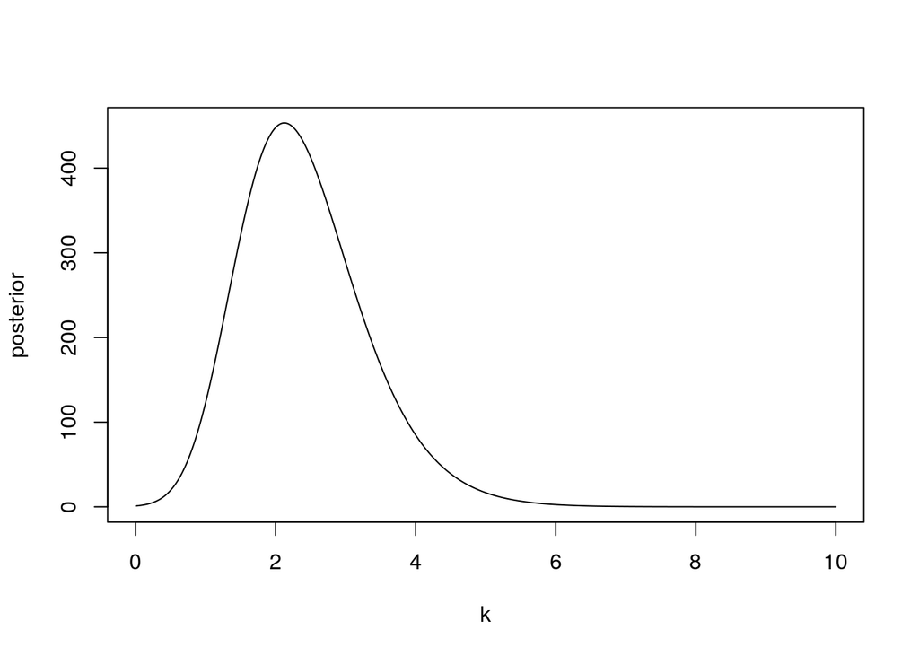

2. Find the (approximate) posterior mode of κ from the information in a).

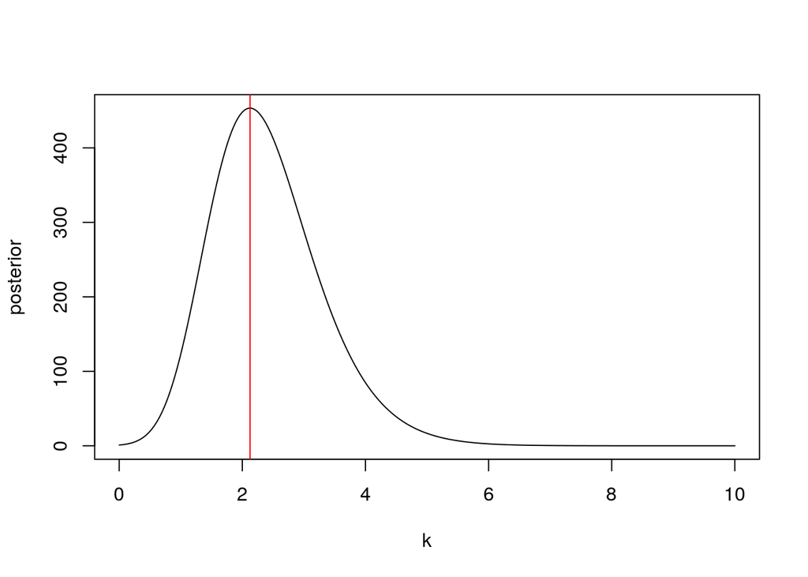

##Code Appendix

```r
knitr::opts_chunk$set(echo = TRUE)
#1.
#a).

avg <- c()
sdv <- c()
for (n in c(1,10,100,1000,10000)) {
  dist <- rbeta(n = n,shape1 = 2+5,shape2 = 2+15)
  #plot(dist)
  avg <- c(avg,mean(dist))
  sdv <- c(sdv, sd(dist))
}

a = 7
b = 17
mean_th = a/(a+b)
sd_th = a*b/(((a+b)^2) * (a+b+1))

print("True mean")
print(mean_th)
print("True sd")
print(sd_th)

#E = (alpha + s)/(alpha + s +beta+ f)
# = (alpha + 5)/(alpha + 5+beta + 15)
# = (alpha + 5)/(alpha + beta + 20)
# = 7/24 = 0.2916667

plot(c(1,10,100,1000,10000),avg, type = "l", ylim = c(0,0.4), ylab = "sd, mean")
lines(c(1,10,100,1000,10000),sdv, col="red")

hist(rbeta(50,a,b),freq = FALSE, breaks = 20)

hist(rbeta(100,a,b),freq = FALSE, breaks = 20)

hist(rbeta(500,a,b),freq = FALSE, breaks = 20)

hist(rbeta(1000,a,b),freq = FALSE, breaks = 20)

#b).
dist <-rbeta(n = 10000,shape1 = 2+5,shape2 = 2+15)
print("simulated probability")
sum(dist>0.3)/length(dist)
print("exact probability")
1-pbeta(0.3,shape1 = 2+5,shape2 = 2+15)

#c).
log_odds<-log(dist/(1-dist))
hist(log_odds)
density(log_odds)

#2.
#a).
obs <- c(44,25,45,52,30,63,19,50,34,67)

n <- 10000
tau2 <- sum((log(obs)-3.7)^2)/(length(obs))
posterior <- ((length(obs))*tau2)/rchisq(n = n, df = length(obs))
hist(posterior)

#We compare mean of simulated posterior and theoretical value
#simulated:
print("Simulated mean")
mean(posterior)
print("Simulated variance")
var(posterior)

#theoretical:
print("Theoretical mean")
(length(obs)*tau2)/(length(obs)-2)
print("Theoretical variance")
(2*length(obs)^2*tau2^2)/(((length(obs)-2)^2) * (length(obs)-4))

#b).
G <- 2* pnorm(q = sqrt(posterior)/sqrt(2), mean = 0, sd = 1)-1
hist(G, breaks = 30)

#c).
#90% equal tail credible interval
G_sort <- sort(G)
G_cut <- G_sort[(length(G_sort)*0.05):(length(G_sort)*0.95-1)]
hist(G, breaks = 30)
abline(v=min(G_cut), col = "red")
abline(v=max(G_cut), col = "red")

#3.
#a).
wind_dir <- c(40,303,326,285,296,314,20,308,299,296)
radians <- c(-2.44,2.14,2.54,1.83,2.02,2.33,-2.79,2.23,2.07,2.02)

mu <- 2.39
k <- seq(0.001, 10.001, by = 0.001)
n <- length(radians)
ml <- exp(k*sum(cos(radians-mu)))/(besselI(k, 0))^n
prior <- exp(-k)
#posterior <- exp(k*sum(cos(radians-mu))-k)/(besselI(k, 0))^n
posterior <- ml * prior #distribution the same but values very small
plot(k,posterior, type = "l")

#b).
plot(k,posterior, type = "l")
abline(v=k[which(posterior==max(posterior))], col = "red")
```